# Matching and Logistic Regression

## The Effect of Catholic School on Student Achievement

Example inspired by Simon Ejdemyr: https://sejdemyr.github.io/r-tutorials/statistics/tutorial8.html

#### Reference links:

1. MatchIt: https://cran.r-project.org/web/packages/MatchIt/vignettes/matchit.pdf
2. Cobalt (optional library for matching plots and extra features): https://cran.r-project.org/web/packages/cobalt/vignettes/cobalt_A0_basic_use.html #might be useful for the assignment
3. kableExtra (for formatting data frames): https://cran.r-project.org/web/packages/kableExtra/vignettes/awesome_table_in_html.html
4. Stargazer (for formatting model outputs): https://www.jakeruss.com/cheatsheets/stargazer/
5. Video overview of matching concepts: https://fr.coursera.org/lecture/crash-course-in-causality/overview-of-matching-JQfPC #video can be very helpful

```r
library(dplyr) # for data wrangling
library(ggplot2) # for creating plots
library(stargazer) # for formatting model output
library(kableExtra) # for formatting data frames
library(MatchIt) # for matching

set.seed(123) # for consistent results
```

### Data Prep and EDA

First, let’s read in the data. We will remove a few variables that won’t be useful for our analysis. Then, we will compare the students *pre-matching* on their standardized math scores (c5r2mtsc_std).

```r
ecls <- read.csv("data/ecls.csv")
#whether or not being in a catholic school affects your math score
#all these factors have wack labels, you could consider renaming them

ecls <- ecls %>%
  select(-childid, -race, -w3daded,
         -w3momed, -w3inccat)
#select allows us to minus things (-) and remove them from our selection. Makes it easier to work with

ecls %>%
  group_by(catholic) %>% #whether they went to catholic school or not
  summarise(n_students = n(), #summary statistics, we're looking for nstudents [n() gives you a count], mean math score [which is equal to the mean of factor name "c5r2mtsc_std"], and then we run it
            mean_math = mean(c5r2mtsc_std),
            std_error = sd(c5r2mtsc_std) / sqrt(n_students)) %>% #she says this is "just for fun"; that's the formula for std.error

#this could count for our assignment. But we could make it a lot more aesthetic

  round(2) %>% # round the results to the 2nd decimal point
  kable() %>% # create kable table
  kable_styling() # view kable table
```

| catholic | n_students | mean_math | std_error |
| --- | --- | --- | --- |
| 0 | 9568 | -0.03 | 0.01 |
| 1 | 1510 | 0.19 | 0.02 |

We can see that we have many more students that did not attend Catholic school than those who did, and the Catholic school students have a mean math score that is higher.

#The above is basically how you would answer the assignment

### NATE

First, let’s calculate the NATE of Catholic school on student achievement (without adjusting for any covariates) using a t-test to compare the means of the two groups.

```r
t.test(ecls$c5r2mtsc_std ~ ecls$catholic)
```

```
##
##  Welch Two Sample t-test
##
## data:  ecls$c5r2mtsc_std by ecls$catholic
## t = -9.1069, df = 2214.5, p-value < 2.2e-16
## alternative hypothesis: true difference in means is not equal to 0
## 95 percent confidence interval:
##  -0.2727988 -0.1761292
## sample estimates:
## mean in group 0 mean in group 1
##     -0.03059583      0.19386817
```

#we have a tiny p-value so it’s statistically significant, #mean in control group and in treatment group.. #NATE’s easy!

### Balance Table

Now, let’s create a balance table to identify the relevant co-variates in the unmatched dataset. #This is the hardest part of the task: point is to idenitfy which variables we want to match on, we want to find the confounder where the difference is the biggest and then match them.

```r
ecls %>%
  group_by(catholic) %>% #cleans up the table and allows us to observe based on their religion
  summarise_all(funs(mean(., na.rm = T))) %>% # summarize the mean of every variable; it's a fancy new summarize function that does it all at once #funs tells us which function we want to use to summarise, na.rm=true as usual to remove N/As in our mean.
  t() %>% # transpose data; i.e. to flip it so it's cleaner (just for your viewing pleasure) - tehcnically, your balance table is done here. But you can make it better from below onwards. Transpose turns it into a matrix from a dataframe.
  as.data.frame() %>% # after transposing, convert from matrix to df so that we can work with it
  add_rownames("variable") %>% # rownames to explicit column #this isn't necessary, but for looks
  rename(no_catholic = V1, catholic = V2) %>% # rename columns that are created by as.data.frame
  mutate(difference = catholic - no_catholic,
         differencePerc = difference / (catholic + no_catholic)) %>% # create new columns for difference between groups
  #we're basically creating new columns too
  mutate_if(is.numeric, round, 3) %>% # round numeric columns; because without is.numeric, it would've rounded off text too, which obviously doesn't work.
  kable() %>% # create kable table #this creates the html
  kable_styling() # view kable table #does all the spicy stuff
```

| variable | no_catholic | catholic | difference | differencePerc |
| --- | --- | --- | --- | --- |
| catholic | 0.000 | 1.000 | 1.000 | 1.000 |
| race_white | 0.556 | 0.725 | 0.169 | 0.132 |
| race_black | 0.136 | 0.054 | -0.083 | -0.436 |
| race_hispanic | 0.181 | 0.131 | -0.050 | -0.161 |
| race_asian | 0.066 | 0.052 | -0.014 | -0.118 |
| p5numpla | 1.133 | 1.093 | -0.040 | -0.018 |
| p5hmage | 37.561 | 39.575 | 2.014 | 0.026 |
| p5hdage | 40.392 | 41.988 | 1.596 | 0.019 |
| w3daded_hsb | 0.488 | 0.259 | -0.229 | -0.306 |
| w3momed_hsb | 0.464 | 0.227 | -0.237 | -0.343 |
| w3momscr | 43.114 | 47.492 | 4.379 | 0.048 |
| w3dadscr | 42.713 | 46.356 | 3.643 | 0.041 |
| w3income | 54889.159 | 82074.301 | 27185.141 | 0.198 |
| w3povrty | 0.219 | 0.038 | -0.181 | -0.705 |
| p5fstamp | 0.129 | 0.015 | -0.114 | -0.788 |
| c5r2mtsc | 50.209 | 52.389 | 2.180 | 0.021 |
| c5r2mtsc_std | -0.031 | 0.194 | 0.224 | 1.375 |

```r
#we can make things interactive with kable, even adding _footnotes_
```

We can see that the largest magnitude differences are for:

- variables on race
- w3momed_hsb: dummy variable with 1 = mother’s education level is high school or below, 0 = some college or above
- w3income: family income
- w3povrty: poverty score dummy
- p5fstamp: food stamp dummy

### Exploring MatchIt

#when we’re doing matching, we then use the matchit library (only works on binary variables) MatchIt is designed for causal inference with a dichotomous treatment variable and a set of pretreatment control variables. Any number or type of dependent variables can be used.

The basic syntax is as follows:  
*matched <- matchit(treat ~ x1 + x2, data = mydata)*

MatchIt is capable of using several matching methods:

- Exact (*method = “exact”*): The simplest version of matching is exact. This technique matches each treated unit to all possible control units with exactly the same values on all the covariates, forming subclasses such that within each subclass all units (treatment and control) have the same covariate values.
- Subclassification (*method = “subclass”*): When there are many covariates (or some covariates can take a large number of values), finding sufficient exact matches will often be impossible. The goal of subclassification is to form subclasses, such that in each the distribution (rather than the exact values) of covariates for the treated and control groups are as similar as possible.
- Nearest Neighbor (*method = “nearest”*): Nearest neighbor matching selects the best control matches for each individual in the treatment group. Matching is done using a distance measure (propensity score) specified by the distance option (default = logit). #distance means propensity score
- As well as optimal matching, full matching, genetic matching, and coarsened exact matching, all of which are detailed in the documentation.

A few additional arguments are important to know about:

- *distance*: this refers to propensity scores. There are many options for how to calculate these within MatchIt.
- *discard*: specifies whether to discard units that fall outside some measure of support of the distance measure (default is “none”, discard no units). For example, if some treated units have extremely high propensity scores that are higher than any control units, we could drop those.
- *replace*: logical value indicating whether each control unit can be matched to more than one treated unit (default is *replace = FALSE*, each control unit is used at most once). #we usually will do replace = true
- *ratio*: the number of control units to match to each treated unit (default = 1).
- There are also some optional arguments for most of the matching methods, which you can read about in the documentation if you are interested. #we would just do ratio = 5

### Exact Matching

We can use a combination of the results from our balance table and theory to identify which variables to use for matching. Let’s perform an exact match with:

- race_white: Is the student white (1) or not (0)?
- p5hmage: Mother’s age
- w3income: Family income
- p5numpla: Number of places the student has lived for at least 4 months
- w3momed_hsb: Is the mother’s education level high-school or below (1) or some college or more (0)?

```r
# first we must omit missing values (MatchIt does not allow missings)
match_data <- ecls %>%
  select(catholic, c5r2mtsc_std, race_white, p5hmage,
         w3income, p5numpla, w3momed_hsb) %>%  #we are only selecting the variables we need (see above)
  na.omit() #it's going to drop anyone with missing values

# perform exact match
exact_match <- matchit(catholic ~ race_white + p5hmage + w3income +
                         p5numpla + w3momed_hsb,
                       method = "exact",
                       data = match_data)

# grab the matched data
data_exact_match <- match.data(exact_match)

# estimate t-test again
t.test(data_exact_match$c5r2mtsc_std ~ data_exact_match$catholic)
```

```
##
##  Welch Two Sample t-test
##
## data:  data_exact_match$c5r2mtsc_std by data_exact_match$catholic
## t = 3.5345, df = 2296.9, p-value = 0.0004166
## alternative hypothesis: true difference in means is not equal to 0
## 95 percent confidence interval:
##  0.04483995 0.15660528
## sample estimates:
## mean in group 0 mean in group 1
##       0.3193214       0.2185988
```

```r
#those who didn't go to catholic school have a higher mean math scores, something happens once you've controll for it, can't really remember what it is.
```

Now we can see that the mean in the group that did not attend Catholic school is actually about 0.10 higher than the mean for those who did. The results are statistically significant given that the confidence interval does not contain zero, and we have a fairly small p-value.

### Propensity Scores

If we want to perform non-exact matching, we need propensity scores. We can generate these manually using logistic regression on the unmatched data set.

````r
# create a new column with income by the thousands for more interpretable output
ecls <- ecls %>%
  mutate(w3income_1k = w3income / 1000)

# estimate logit model
m_ps <- glm(catholic ~ race_white + w3income_1k +
              p5hmage + p5numpla + w3momed_hsb,
            family = binomial(), #this is a generalized linear model (glm)
            data = ecls)

# use the stargazer package to view the output
# NOTE: you MUST include results = "asis" in the chunk header for this to be visible once knitted
#see ```{r, results = 'asis'}

stargazer(m_ps, type = "html")
````

|  | *Dependent variable:* |
| --- | --- |
|  | catholic |
| race_white | 0.315*** |
|  | (0.070) |
| w3income_1k | 0.007*** |
|  | (0.001) |
| p5hmage | 0.029*** |
|  | (0.005) |
| p5numpla | -0.144 |
|  | (0.091) |
| w3momed_hsb | -0.694*** |
|  | (0.074) |
| Constant | -3.213*** |
|  | (0.238) |
| Observations | 9,267 |
| Log Likelihood | -3,584.423 |
| Akaike Inf. Crit. | 7,180.846 |
| *Note:* | p<0.1; p<0.05; p<0.01 |

```r
# extract predicted probabilities
# type = "response" option tells R to output probabilities of the form P(Y = 1|X)
prs_df <- data.frame(pr_score = predict(m_ps, type = "response"),
                     catholic = m_ps$model$catholic) # the actual values
#from our logistic regression,  we want to grab the mode, and the catholic thing from that.
#allows us to know for sure that they're going together.

#we only use this for plotting, not matching.
```

Let’s plot the propensity scores by treatment group to explore common support:

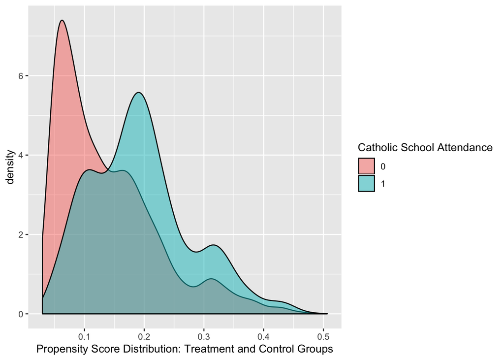

```r
prs_df %>%
  ggplot(aes(x = pr_score, fill = factor(catholic))) + #fill is the color, catholic is just 1&0, so we want to convert it into a factor
  geom_density(alpha = 0.5) + #allows us to make it see through (like opacity)
  labs(x = "Propensity Score Distribution: Treatment and Control Groups",
       fill = "Catholic School Attendance")
```

### Non-Exact Matching

MatchIt can generate propensity scores itself, so we don’t need to manually go through the process above. Let’s try putting together a non-exact matching formula yourself! Try:

- nearest neighbor matching
- with replacement
- with a one-to-one ratio
- on the *match_data* dataset

All the info you need to complete this is available in the Exploring Matching section. Scroll down for the solution when you’re ready ;-)

```r
one_match <- matchit(catholic ~ race_white + w3income + p5hmage +
                       p5numpla + w3momed_hsb,
                     method = "nearest",
                     ratio = 1,
                     replace = TRUE,
                     data = match_data)

summary(one_match)
```

```
##
## Call:
## matchit(formula = catholic ~ race_white + w3income + p5hmage +
##     p5numpla + w3momed_hsb, data = match_data, method = "nearest",
##     ratio = 1, replace = TRUE)
##
## Summary of balance for all data:
##             Means Treated Means Control SD Control  Mean Diff  eQQ Med
## distance           0.1927        0.1379     0.0845     0.0549 5.67e-02
## race_white         0.7411        0.5914     0.4916     0.1497 0.00e+00
## w3income       82568.9357    55485.0210 43961.0872 27083.9146 2.50e+04
## p5hmage           39.5932       37.5658     6.5506     2.0274 2.00e+00
## p5numpla           1.0917        1.1298     0.3910    -0.0380 0.00e+00
## w3momed_hsb        0.2234        0.4609     0.4985    -0.2375 0.00e+00
##               eQQ Mean  eQQ Max
## distance        0.0548 7.60e-02
## race_white      0.1501 1.00e+00
## w3income    27069.1775 6.25e+04
## p5hmage         2.2544 7.00e+00
## p5numpla        0.0399 2.00e+00
## w3momed_hsb     0.2374 1.00e+00
##
##
## Summary of balance for matched data:
##             Means Treated Means Control SD Control Mean Diff eQQ Med  eQQ Mean
## distance           0.1927        0.1927     0.0846    0.0000  0.0036    0.0035
## race_white         0.7411        0.7493     0.4336   -0.0081  0.0000    0.0009
## w3income       82568.9357    81775.6653 46655.3379  793.2703  0.0000 2241.7548
## p5hmage           39.5932       39.6169     5.1757   -0.0237  0.0000    0.1458
## p5numpla           1.0917        1.0777     0.2839    0.0141  0.0000    0.0139
## w3momed_hsb        0.2234        0.2226     0.4162    0.0007  0.0000    0.0130
##              eQQ Max
## distance    1.35e-02
## race_white  1.00e+00
## w3income    6.25e+04
## p5hmage     9.00e+00
## p5numpla    1.00e+00
## w3momed_hsb 1.00e+00
##
## Percent Balance Improvement:
##             Mean Diff.  eQQ Med eQQ Mean  eQQ Max
## distance       99.9987  93.6433  93.6864  82.2762
## race_white     94.5656   0.0000  99.4219   0.0000
## w3income       97.0711 100.0000  91.7184   0.0000
## p5hmage        98.8326 100.0000  93.5313 -28.5714
## p5numpla       63.0544   0.0000  65.2263  50.0000
## w3momed_hsb    99.6886   0.0000  94.5158   0.0000
##
## Sample sizes:
##           Control Treated
## All          7915    1352
## Matched      1152    1352
## Unmatched    6763       0
## Discarded       0       0
```

We can interpret the resulting output as follows:

- Summary of balance for all data: Comparison of the means for all the data without matching
- Summary of balance for matched data: Comparison of means for matched data. Looking for them to become similar.
- Percent balance improvement: Higher is better, close to 100 is ideal.
- Sample sizes: How many units were matched in the control/treatment groups.

Now, let’s plot the propensity scores for the treated and untreated units.

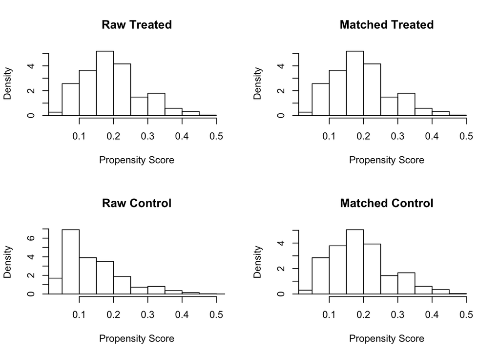

```r
# simple plot - check out the cobalt package for fancier options, or use ggplot2 to create your own!
plot(one_match, type = "hist")
```

Try extracting the data from *one_match* and creating a balance table like the one we did before, just this time using the new data. Scroll down for the answer when you’re ready.

```r
# grab data set
data_prop_match <- match.data(one_match)

# check balance
data_prop_match %>%
  group_by(catholic) %>%
  summarise_all(funs(mean)) %>%
  t() %>%
  as.data.frame() %>%
  add_rownames("variable") %>%
  rename(no_catholic = V1, catholic = V2) %>%
  mutate(difference = catholic - no_catholic,
         differencePerc = difference / (catholic + no_catholic)) %>%
  mutate_if(is.numeric, round, 3) %>%
  kable() %>%
  kable_styling()
```

| variable | no_catholic | catholic | difference | differencePerc |
| --- | --- | --- | --- | --- |
| catholic | 0.000 | 1.000 | 1.000 | 1.000 |
| c5r2mtsc_std | 0.373 | 0.210 | -0.163 | -0.280 |
| race_white | 0.741 | 0.741 | 0.000 | 0.000 |
| p5hmage | 39.502 | 39.593 | 0.091 | 0.001 |
| w3income | 80265.273 | 82568.936 | 2303.662 | 0.014 |
| p5numpla | 1.079 | 1.092 | 0.013 | 0.006 |
| w3momed_hsb | 0.236 | 0.223 | -0.013 | -0.028 |
| distance | 0.190 | 0.193 | 0.003 | 0.008 |
| weights | 1.000 | 1.000 | 0.000 | 0.000 |

Those means look very close. Hooray.

Finally, estimate the treatment effect on the matched data set:

```r
t.test(data_prop_match$c5r2mtsc_std ~ data_prop_match$catholic)
```

```
##
##  Welch Two Sample t-test
##
## data:  data_prop_match$c5r2mtsc_std by data_prop_match$catholic
## t = 4.4453, df = 2348.9, p-value = 9.184e-06
## alternative hypothesis: true difference in means is not equal to 0
## 95 percent confidence interval:
##  0.09116349 0.23507986
## sample estimates:
## mean in group 0 mean in group 1
##       0.3727895       0.2096679
```

As with the exact matching, we can see that those that did not attend Catholic school performed better on the test than those who did, and the results are statistically significant.

We can see the direction and magnitude of the covariate effects using a simple linear model:

```r
lm_matched <- lm(c5r2mtsc_std ~ catholic + race_white + p5hmage +
                  I(w3income / 1000) + p5numpla + w3momed_hsb,
                 data = data_prop_match)

# use the stargazer package to view the output
# NOTE: you MUST include results = "asis" in the chunk header for this to be visible once knitted
stargazer(lm_matched, type = "html")
```

|  | *Dependent variable:* |
| --- | --- |
|  | c5r2mtsc_std |
| catholic | -0.175*** |
|  | (0.034) |
| race_white | 0.315*** |
|  | (0.040) |
| p5hmage | 0.012*** |
|  | (0.003) |
| I(w3income/1000) | 0.003*** |
|  | (0.0004) |
| p5numpla | -0.050 |
|  | (0.058) |
| w3momed_hsb | -0.287*** |
|  | (0.042) |
| Constant | -0.468*** |
|  | (0.154) |
| Observations | 2,504 |
| R<sup>2</sup> | 0.112 |
| Adjusted R<sup>2</sup> | 0.110 |
| Residual Std. Error | 0.860 (df = 2497) |
| F Statistic | 52.744*** (df = 6; 2497) |
| *Note:* | p<0.1; p<0.05; p<0.01 |